# tidyverse

##### Task 8

Create a stacked histogram for the variable `price` and color by variable `cut`

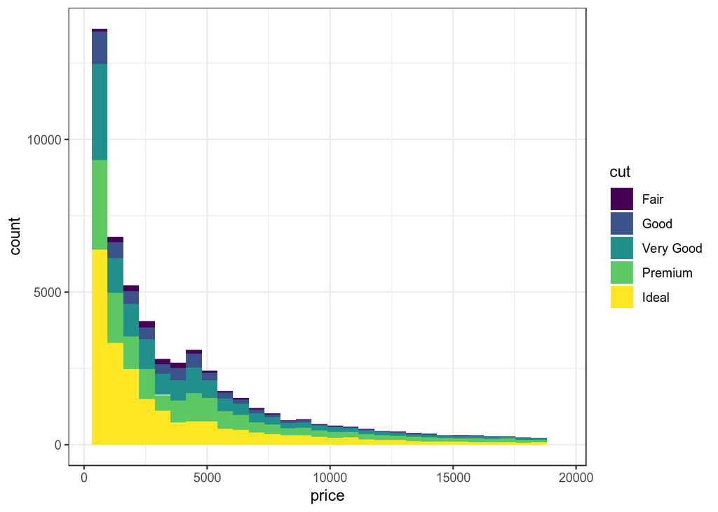

##### Task 9

Create a side-to-side histogram for the variable `price` and color by variable `cut` using argument `position = "dodge"`.

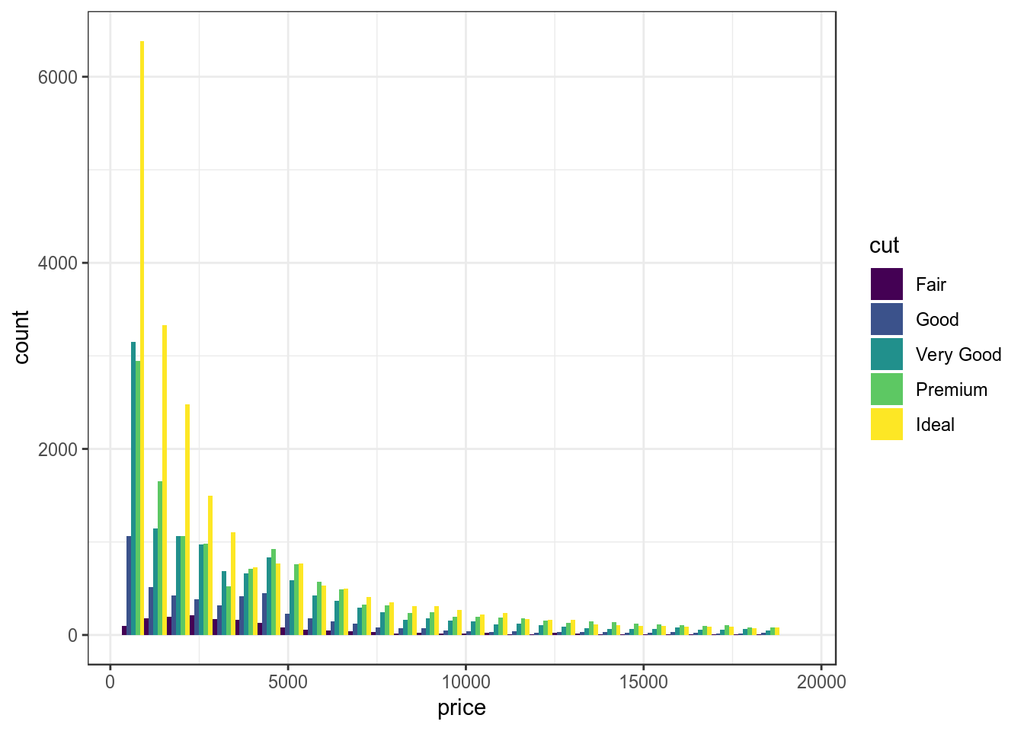

#### 6.5 Density plot

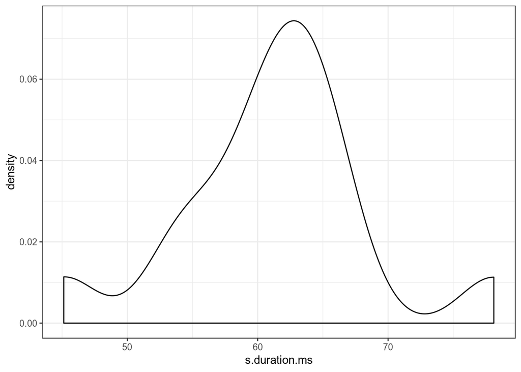

```r
homo %>%
  ggplot(aes(s.duration.ms)) +
  geom_density()
```

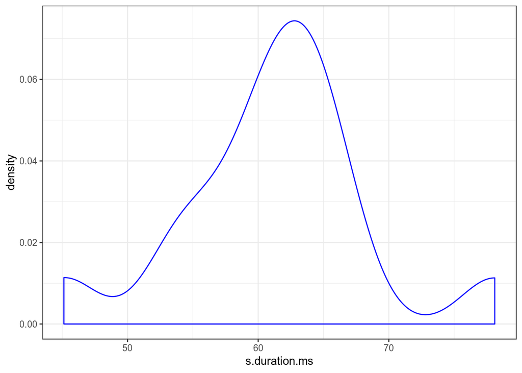

```r
homo %>%
  ggplot(aes(s.duration.ms)) +
  geom_density(color = "blue")
```

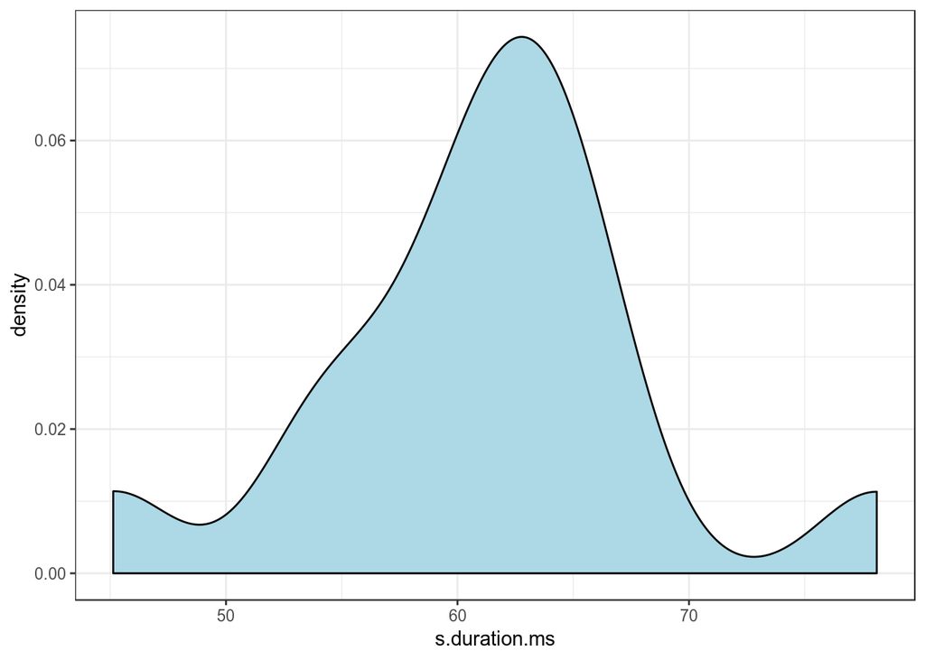

```r
homo %>%
  ggplot(aes(s.duration.ms)) +
  geom_density(fill = "lightblue")
```

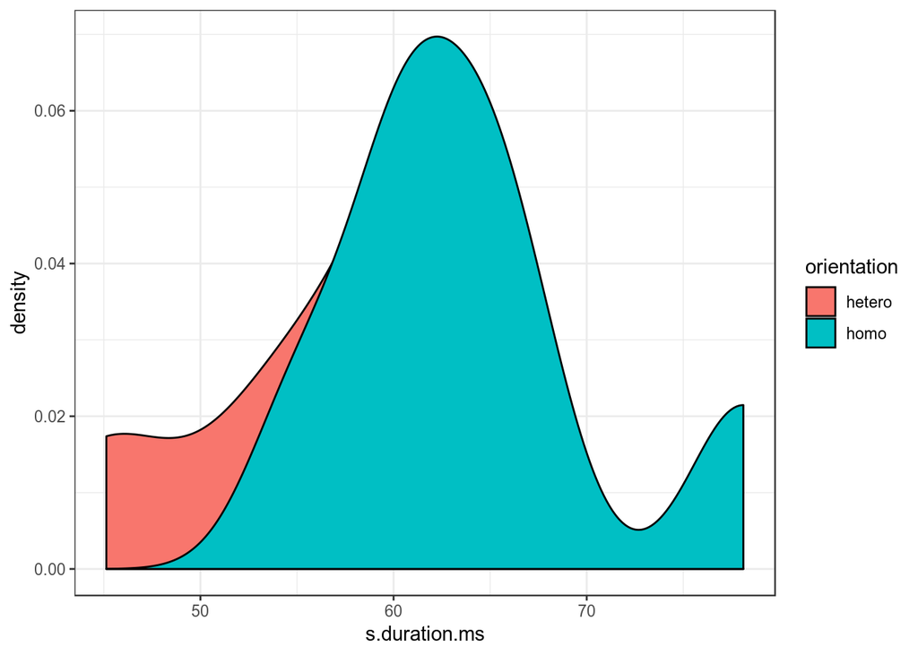

```r
homo %>%
  ggplot(aes(s.duration.ms, fill = orientation)) +
  geom_density()
```

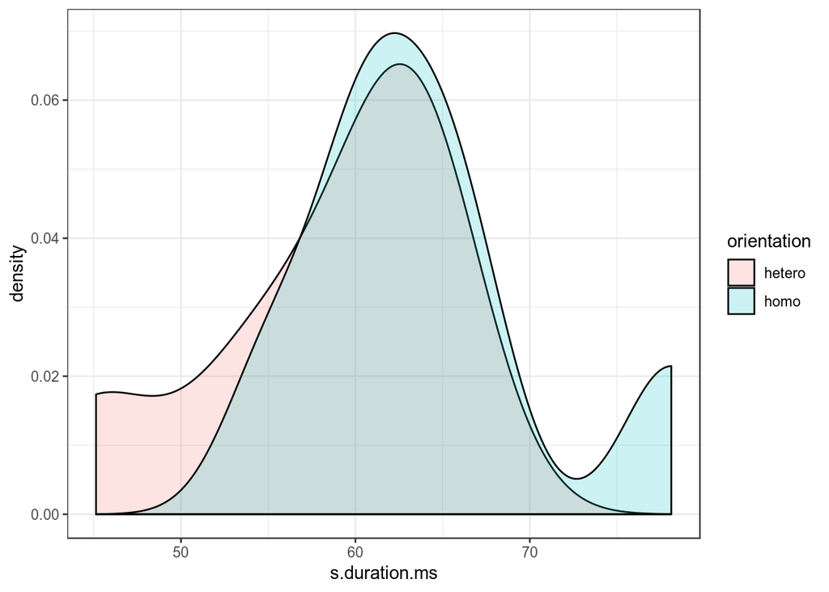

```r
homo %>%
  ggplot(aes(s.duration.ms, fill = orientation)) +
  geom_density(alpha = 0.2)
```

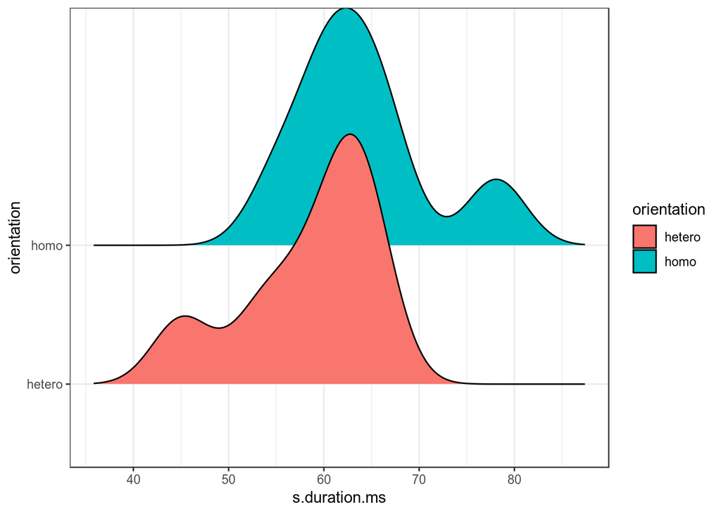

```r
library(ggridges)
homo %>%
  ggplot(aes(s.duration.ms, orientation, fill = orientation)) +
  geom_density_ridges()
```

##### Task 10

Create a density plot for the variable `price` and color by variable `cut`. Use argument `alpha = 0.5`.

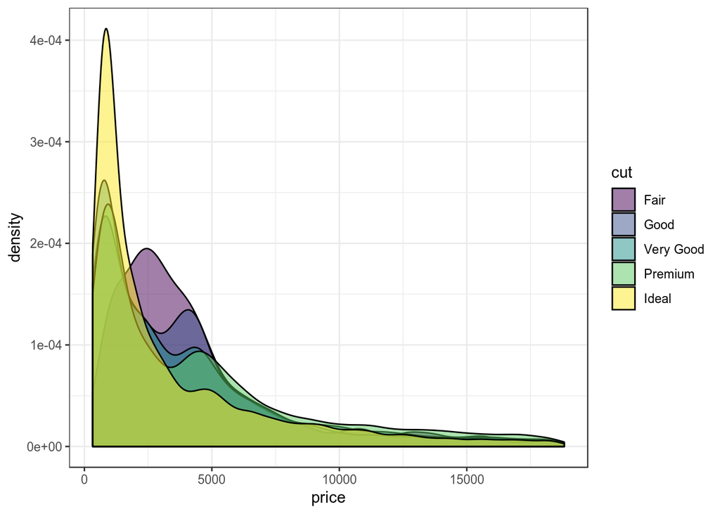

#### 6.7 Facets

##### 6.7.1 `ggplot2::facet_wrap()`

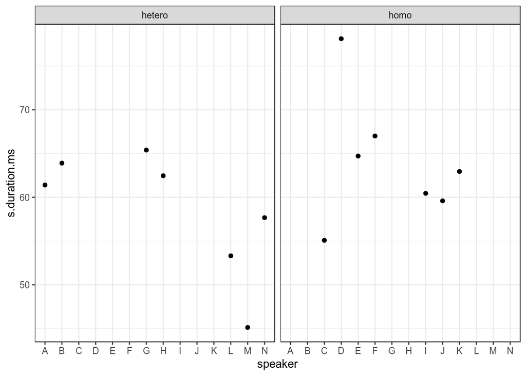

```r
homo %>%
  ggplot(aes(speaker, s.duration.ms))+
  geom_point() +
  facet_wrap(~orientation)
```

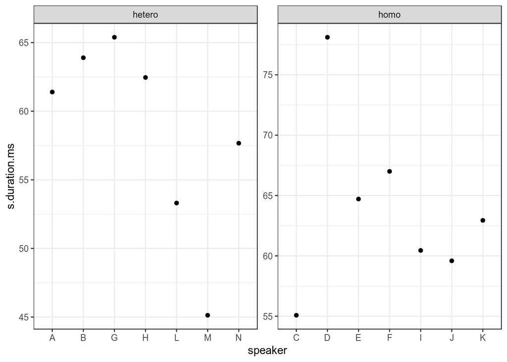

```r
homo %>%
  ggplot(aes(speaker, s.duration.ms))+
  geom_point() +
  facet_wrap(~orientation, scales = "free")
```

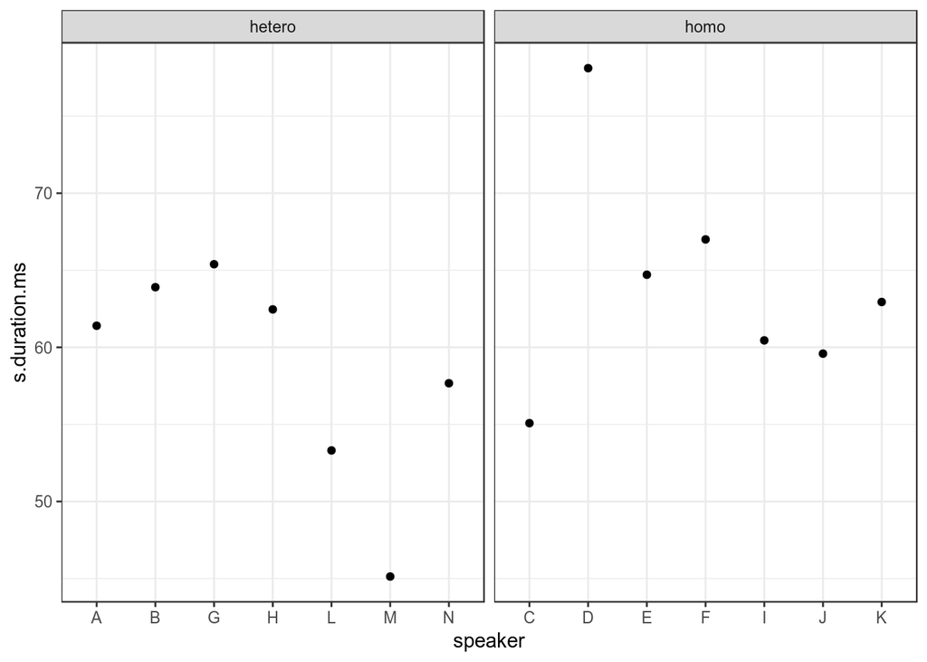

```r
homo %>%
  ggplot(aes(speaker, s.duration.ms))+
  geom_point() +
  facet_wrap(~orientation, scales = "free_x")
```

##### 6.7.2 `ggplot2::facet_grid()`

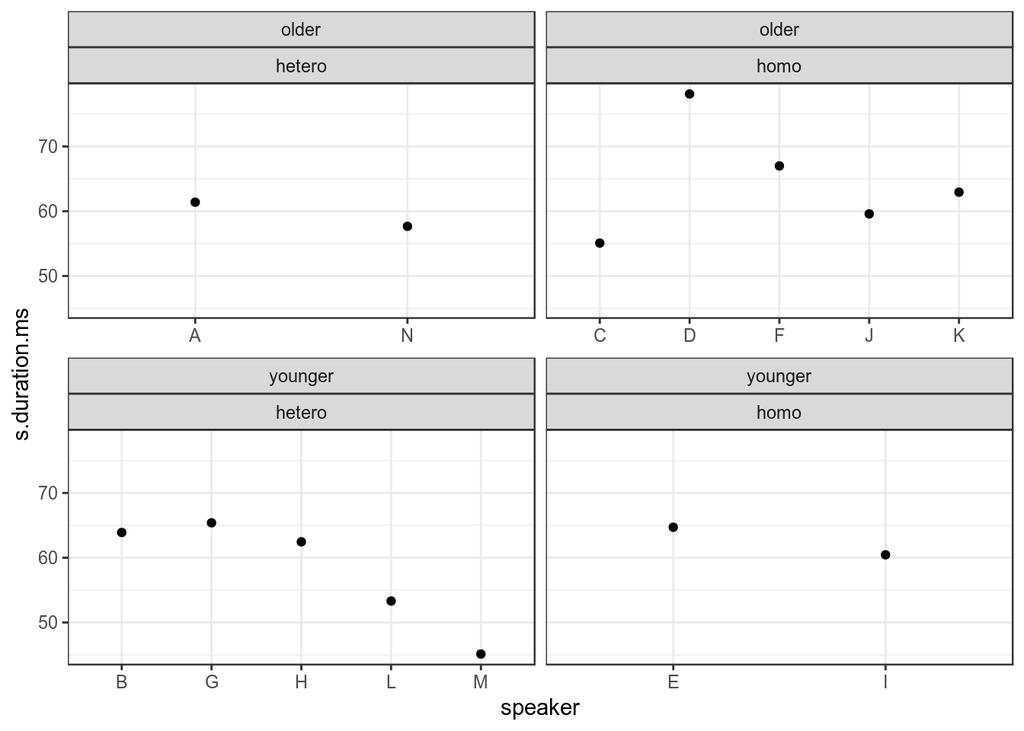

```r
homo %>%
  mutate(older_then_28 = ifelse(age > 28, "older", "younger")) %>%
  ggplot(aes(speaker, s.duration.ms))+
  geom_point() +
  facet_wrap(older_then_28~orientation, scales = "free_x")
```

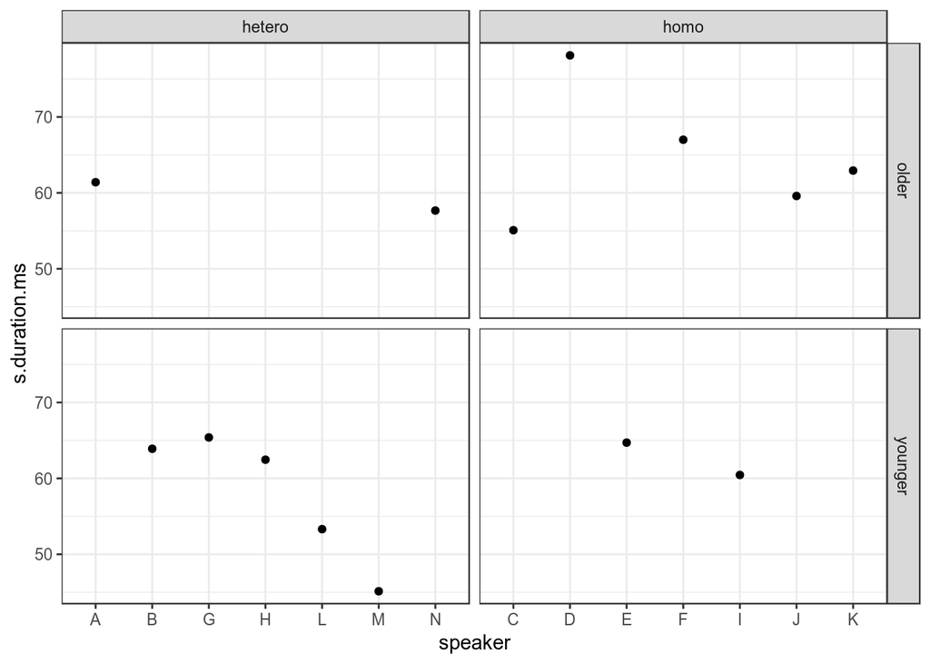

```r
homo %>%
  mutate(older_then_28 = ifelse(age > 28, "older", "younger")) %>%
  ggplot(aes(speaker, s.duration.ms))+
  geom_point() +
  facet_grid(older_then_28~orientation, scales = "free_x")
```

There is also nice argument `margins`:

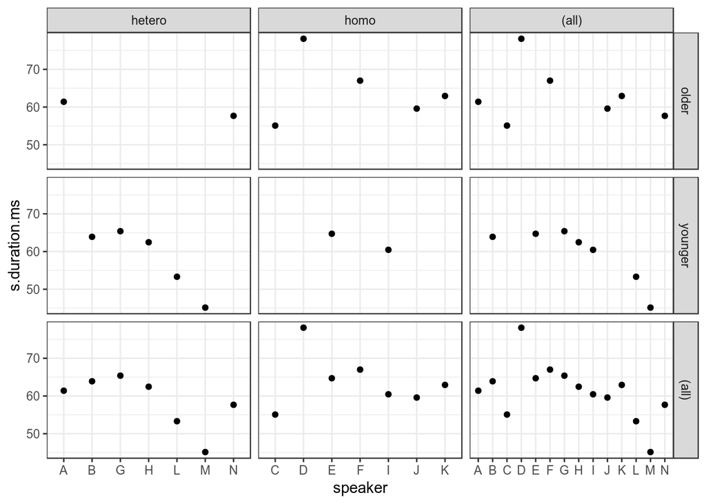

```r
homo %>%
  mutate(older_then_28 = ifelse(age > 28, "older", "younger")) %>%
  ggplot(aes(speaker, s.duration.ms))+
  geom_point() +
  facet_grid(older_then_28~orientation, scales = "free_x", margins = TRUE)
```

Sometimes it is nice to show all data on each facet:

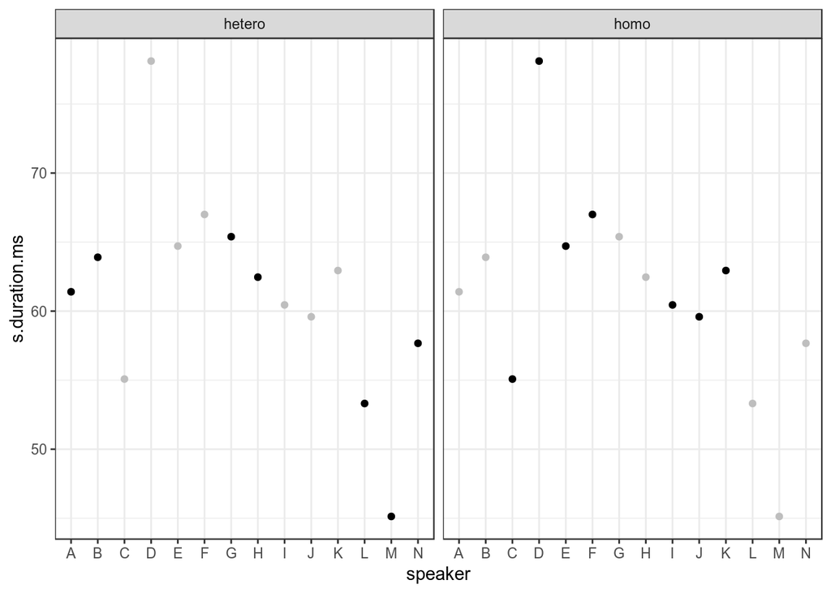

```r
homo %>%
  ggplot(aes(speaker, s.duration.ms))+
  # Add an additional geom without facetization variable!
  geom_point(data = homo[,-9], aes(speaker, s.duration.ms), color = "grey") +
  geom_point() +
  facet_wrap(~orientation)+
  theme_bw()
```

##### Task 11

Reproduce the graph:

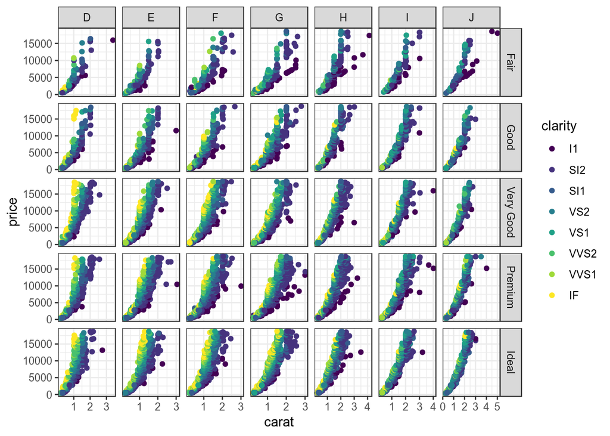